# Reproducible Research: Peer Assessment 1

## Loading and preprocessing the data

```r
activity <- read.csv("activity.csv")
```

## What is mean total number of steps taken per day?

Following code computes an average of steps per day.

```r
library(plyr)
per_day <- ddply(activity, .(date), function(df) {
  data.frame(date=df$date[1], steps=sum(df$steps, na.rm=T))
})

step_mean <- mean(per_day$steps, na.rm=T)
```

It shows the mean is 9354.2295.

## What is the average daily activity pattern?

The following chart shows the change of steps over time.

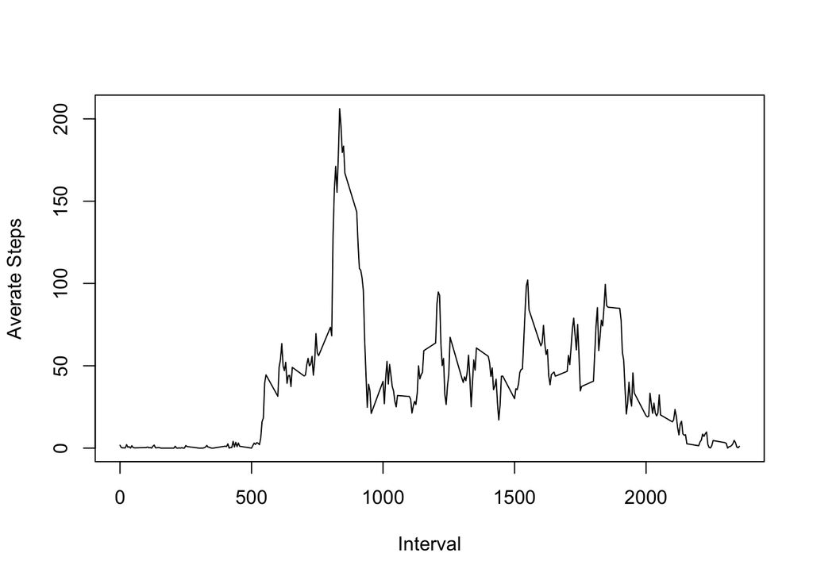

```r
per_step <- ddply(activity, .(interval), function(df) {
  data.frame(interval=df$interval[1], steps=mean(df$steps, na.rm=T))
})
plot(per_step$interval, per_step$steps, type="l", xlab="Interval", ylab="Averate Steps")
```

```r
max_step <- max(per_step$steps, na.rm=T)
max_step_interval <- per_step$interval[per_step$steps == max_step]
max_step_interval
```

```
## [1] 835
```

Also, a person takes the largest number of steps at interval 835 in average.

## Imputing missing values

```r
na_counts <- length(which(is.na(activity$step)))
na_counts
```

```
## [1] 2304
```

According to the code above, there are 2304 NA instances. Let’s see whether it is reasonable to just drop these values.

Following code fills the NA records with the average step count.

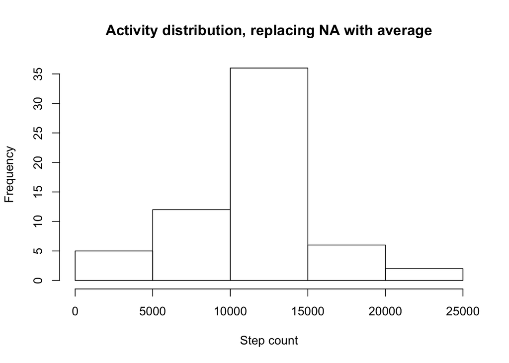

```r
step_mean <- mean(per_step$steps)
filled_activity = activity
filled_activity[is.na(activity$steps),]$steps <- step_mean
filled_per_day <- ddply(filled_activity, .(date), function(df) {
  data.frame(date=df$date[1], steps=sum(df$steps))
})

filled_steps_mean <- mean(filled_per_day$steps)
filled_steps_median <- median(filled_per_day$steps)
hist(filled_per_day$steps, main="Activity distribution, replacing NA with average", xlab="Step count")
```

Compare the histgram with the one from the table that drops NAs.

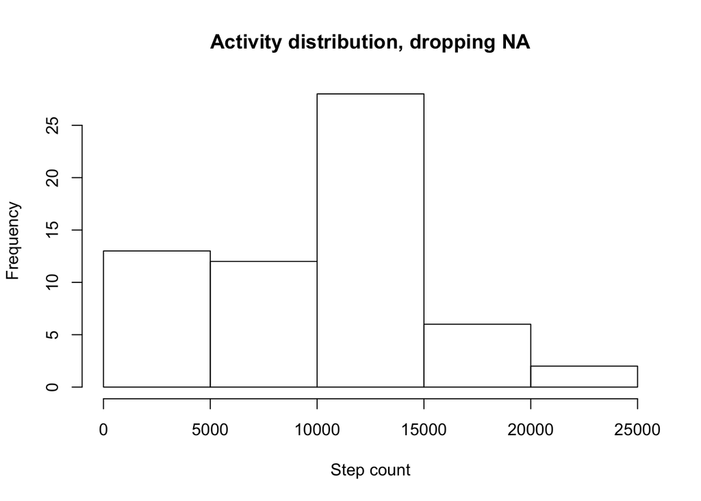

```r
steps_mean <- mean(per_day$steps)
steps_median <- median(per_day$steps)
hist(per_day$steps, main="Activity distribution, dropping NA", xlab="Step count")
```

Here is the mean and the median of both filled nad dropped versions of tables:

- Mean (Filling NA with average): 1.0766 × 10<sup>4</sup>
- Median (Filling NA with average): 1.0766 × 10<sup>4</sup>
- Mean (Dropping NA): 9354.2295
- Median (Dropping NA): 10395

## Are there differences in activity patterns between weekdays and weekends?

```r
library(lubridate)
```

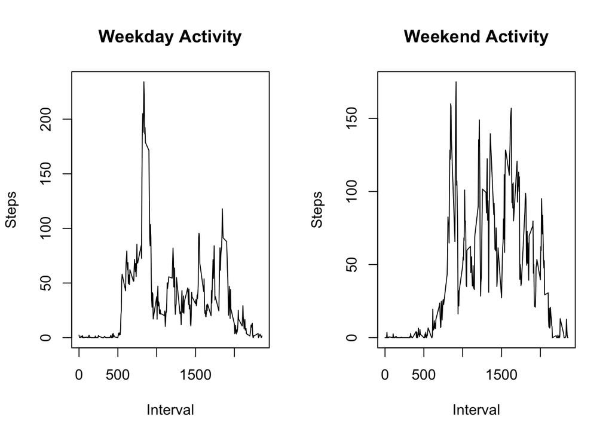

```r
activity$ymd <- ymd(as.character(activity$date))
activity$weekends <- weekdays(activity$ymd) %in% c("Saturday", "Sunday")
per_step_per_daytype <- ddply(activity, .(weekends), function(df) {
  ddply(df, .(interval), function(dg) {
    data.frame(weekends=dg$weekends[1], interval=dg$interval[1], steps=mean(dg$steps, na.rm=T))
  })
})

activity_weekdays <- per_step_per_daytype[!per_step_per_daytype$weekends,]
activity_weekends <- per_step_per_daytype[ per_step_per_daytype$weekends,]
par(mfrow=c(1,2))
plot(activity_weekdays$interval, activity_weekdays$steps, type="l",
     xlab="Interval", ylab="Steps", main="Weekday Activity")
plot(activity_weekends$interval, activity_weekends$steps, type="l",
     xlab="Interval", ylab="Steps", main="Weekend Activity")
```

The chart shows the weekday activity is biased to morning. In contrast, the weekend activity is scattered across the day.